# Human health effects due to proximity to concentrated animal-feeding operations (CAFO)

# Project Summary : Outcomes and exposures evaulated in the published literture from 2014 to 2020.

Livestock farming has experienced a significant transformation in the 60 years, moving from small, family-owned farms to large farms. Two terms are used to classify those large animal operations: animal feeding operations (AFO) and concentrated animal feeding operations (CAFO). The U.S. Environmental Protection Agency (EPA) defines an AFO as an agricultural enterprise where animals are kept and raised in confined situations. AFOs congregate animals, feed, manure and urine, dead animals, and production operations on a small land area. Likewise, for the EPA, CAFO is a term used for a large concentrated AFO. More precisely, a CAFO is an AFO with more than 1000 animal units confined on site for more than 45 days during the year. The growth and popularity of this type of operations have been accompanied by concerns about potential harmful effects that animal facilities could have on nearby communities. It has been suggested that facilities that confine animals indoors for feeding might represent a health hazard for surrounding communities because of exposure to odors, emissions and other infectious agents. To understand and estimate the impacts of CAFO on the health of nearby communities, several studies have been carried out over the past 30 years.

# Purpose of the Project

In March 2020, the National Pork Board asked our group to provide a summary of the outcome and exposures reported in studies published on the topic of CAFOS and community health since 2014. Our group has performed two systematic reviews that summarize and assess the findings of previous publications approaching the association between animal-feeding operations and the measures of the health of individuals living near animal-feeding operations. In the 2014 review, we reported that 16 publications were relevant to the topic. For this project, we evaluated the outcomes and exposure reported in potentially relevant papers published since 2014.

# Brief Summary

To summarize these combinations, the reported health outcome measures and measures used to assess exposure to animal feed operations were further grouped into broad outcome and exposure categories, respectively. For example, if a study reported asthma as a health outcome, this outcome was categorized into the more general group of lower respiratory diseases. These broad outcomes categories were created based on the affected body system such as digestive, cardiovascular, etc (Table 2). A similar approach was used for exposure metrics (Table 3). We defined a combination as the pair of a broad outcome category and exposure, for example, lower respiratory disease (broad outcome category) and distance to the nearest CAFO operation (exposure). The rationale for this approach was to manage the data presentation as each author group used slightly different definitions of outcome and exposure.

# Basic Description of the Studies

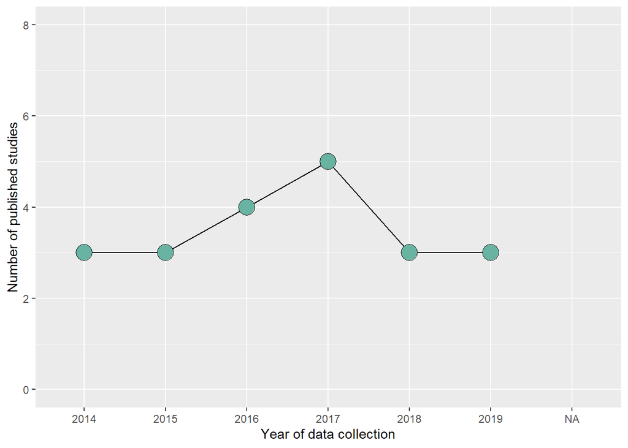

Trendline for the number of studies published since 2014

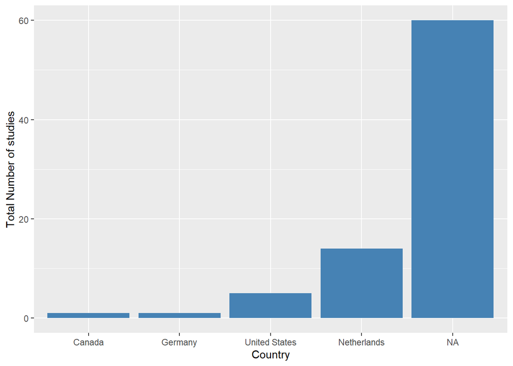

Number of studies published by country since 2014

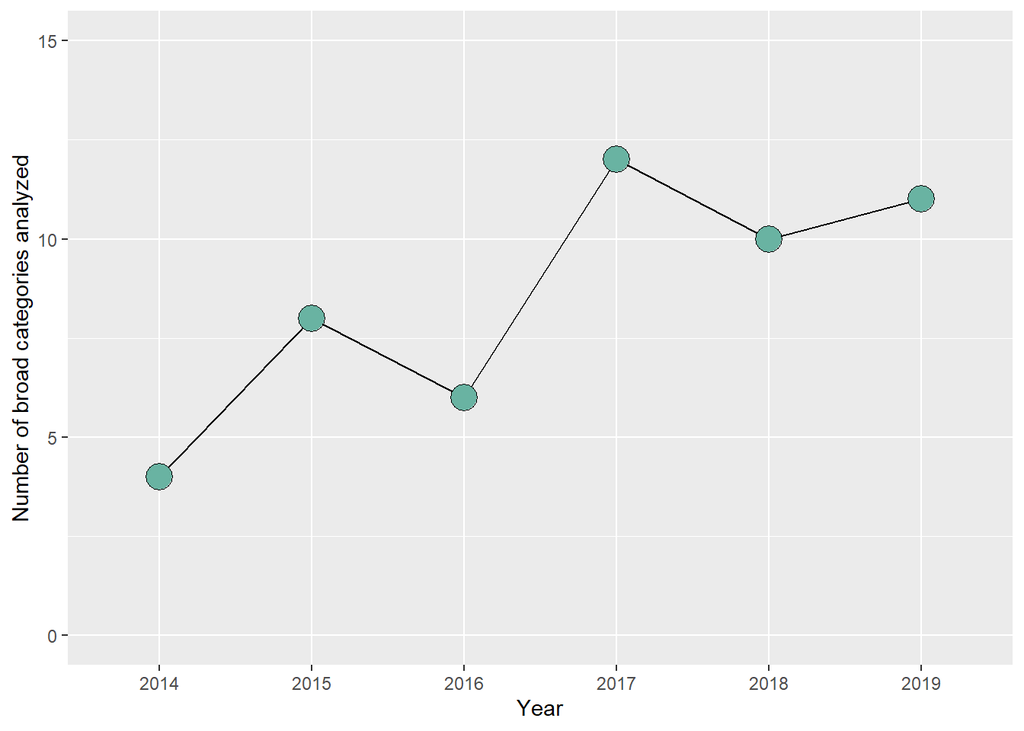

Number of broad outcomes categories analyzed since 2014

# Species considered in the studies

The domestic species studied in the 21 references were cattle, swine, poultry, sheep, goat, mink and horse.These species were analyzed as an exposure and were evaluated in variables such as the type of animal species on the farm, distance from human residence to the farm with any of the mentioned species and density of animals. The swine was the most common specie with a total of 19 studies and was followed by cattle and poultry with 17 (Figure ). When the country is taken into consideration, it is possible to appreciate that in the United States only studies analyzing cattle, poultry and pigs were published, while in the Netherlands the studies included all the species. To be more exact, in the United States three studies were published considering swine and cattle and two considering poultry (Table 4).

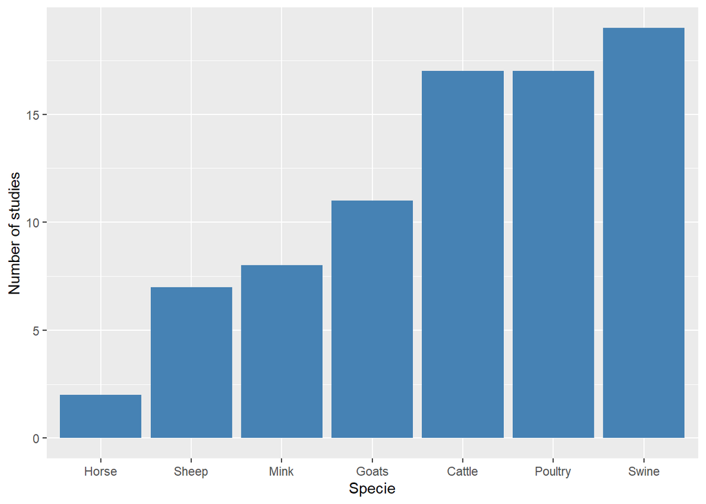

Number of studies published by species in the twenty one references included

# Health outcomes of the studies

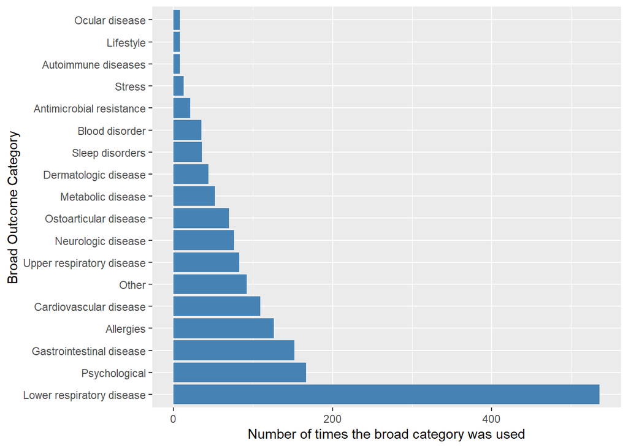

Number of times the broad outcome category was used in the studies published since 2014

# Exposures defined in the studies

There are multiple ways to establish and measure exposure to animal feeding operations. These can be grouped in broader categories which include: emissions, animal and farm density, distance to the nearest CAFO, odors and type of CAFO (swine, poultry, cattle etc.)(Figure ). For the emission category the measure included dust emissions, ammonia (NH3) and particulate matter (PM10). The most common exposure is distance, which is a cheap readily avilable, and imperfect metric for exposure.

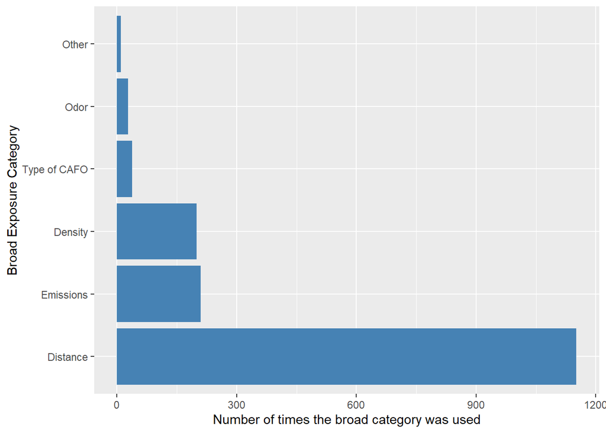

Number of times the broad exposure category was used in the studies published since 2014

## Material and methods

### Study designs eligible

Eligible studies for this update were all types of observational studies reporting any health outcome or measures of the resistance of resident (colonized) bacterial populations measured directly on human subjects. Eligible studies must include more than one unit of measurement of exposure (e.g., more than one farm per exposure group) to be included because of concerns about confounding. Additionally, studies where the unit of measurement of the outcome was a population aggregate were excluded. The populations of interest were humans living in communities near and not near animal-feeding operations that might reasonably be described as industrial. This criterion excludes studies that assess the impact of occupational exposure to livestock. Production systems that appeared to be grass-based, nomadic, or confined smallholder operations were not relevant to the update. Studies and outcomes that related to environment such as air, water, and soil or built environment were not eligible. Animal models of human disease were not eligible because it is unclear how an animal model of human disease would accurately reproduce short- and long-term effects of exposure to AFOs.

### Information sources and search

The MEDLINE® databases was searched. Eligible studies reported exposure to an AFO and an individual-level human health outcome. Two reviewers performed study selection and data extraction. The syntax used in the latest systematic review was used here limiting the time from 2014 to 2020. The strategy comprised two concepts animal feeding operations and community health. Studies that only reported animal health outcomes were excluded.

### Study selection

763 studies were obtained and uploaded into online systematic review software (DistillerSR®, Ottawa, ON, Canada). During Level 1 screening, the following question to assess the relevance of citation abstracts and titles was used:

1. Does the title and/or abstract describe primary research reporting the association between livestock (intensive- not pastoral) and human interactions (direct or indirect) and measures of human health measured on humans?

Citations were excluded if the reviewer answered “no” to this question. 50 studies passed Level 1 and progressed to Level 2. The following questions to assess each article retained after the full-text evaluation were used:

1. Does the study use a unit of analysis at the individual human level in the community (but not occupational, such as farm worker)?
2. Does the study include more than one unit of measurement of exposure?

The study was excluded if the reviewer answered “no” to either question. If the reviewer answered “yes” to both questions, the study progressed to the data extraction. Finally, 21 studies passed Level 2 and passed to the extraction of information.

### Data collection process

For each of the 21 studies, the reviewer extracted the study year, the study population’s location (country), the reported health outcome measures as well as the measure used to assess the exposure to animal feeding operations. Subsequently, these outcomes and exposures were categorized into broad categories in order to summarize and get some descriptive information.

Number of times broad category was combinated by years

|  | 2014 | 2015 | 2016 | 2017 | 2018 | 2019 |
| --- | --- | --- | --- | --- | --- | --- |
| Allergies | 12 | 23 | 12 | 37 | 0 | 42 |
| Antimicrobial resistance | 21 | 0 | 0 | 0 | 0 | 0 |
| Autoimmune diseases | 0 | 0 | 0 | 0 | 8 | 0 |
| Blood disorder | 0 | 0 | 0 | 17 | 0 | 18 |
| Cardiovascular disease | 0 | 0 | 0 | 65 | 8 | 36 |
| Dermatologic disease | 0 | 0 | 6 | 22 | 16 | 0 |
| Gastrointestinal disease | 3 | 7 | 12 | 71 | 41 | 18 |
| Lifestyle | 0 | 0 | 0 | 0 | 8 | 0 |
| Lower respiratory disease | 24 | 127 | 48 | 201 | 22 | 114 |
| Metabolic disease | 0 | 0 | 0 | 34 | 0 | 18 |
| Neurologic disease | 0 | 3 | 0 | 55 | 0 | 18 |
| Ocular disease | 0 | 0 | 0 | 0 | 8 | 0 |
| Ostoarticular disease | 0 | 0 | 0 | 34 | 0 | 36 |
| Other | 0 | 0 | 70 | 0 | 22 | 0 |
| Psychological | 0 | 2 | 0 | 71 | 40 | 54 |
| Sleep disorders | 0 | 1 | 0 | 17 | 0 | 18 |
| Stress | 0 | 13 | 0 | 0 | 0 | 0 |
| Upper respiratory disease | 0 | 1 | 21 | 37 | 6 | 18 |

Health outcomes grouped into broad categories

| Broad Category | Outcome variable | Reference |
| --- | --- | --- |
| Allergies | Allergic conjunctivitis | Hooiveld et al. 2016 |
| Allergies | Allergic rhinitis | Dijk et al. 2017 |
| Allergies | Allergic rhinitis | Smit et al. 2014 |
| Allergies | Allergic rhinitis/Hay fever | Baliatsas et al. 2017 |
| Allergies | Allergic rhinitis/Hay fever | Baliatsas et al. 2019 |
| Allergies | Allergic rhinitisa | Dijk et al. 2017 |
| Allergies | Current allergies | Schultz et al. 2019 |
| Allergies | Hay fever | Hooiveld et al. 2016 |
| Allergies | Lung Allergies | Schultz et al. 2019 |
| Allergies | Nasal allergies | Borlee et al. 2015 |
| Allergies | Nasal Allergies | Schultz et al. 2019 |
| Allergies | Nasal or Lung Allergies & Current allergies | Schultz et al. 2019 |
| Antimicrobial resistance | Methicillin resistant Staphylococcus aureus nasal carriage | Schinasi et al. 2014 |
| Autoimmune diseases | Chronic/long-term diseases: autoimmune diseases | Star et al. 2018 |
| Blood disorder | Anemia | Baliatsas et al. 2017 |
| Blood disorder | Anemia | Baliatsas et al. 2019 |
| Cardiovascular disease | Atherosclerosis | Baliatsas et al. 2017 |
| Cardiovascular disease | Chronic/long-term diseases of the cardiovascular system | Star et al. 2018 |
| Cardiovascular disease | Coronary heart disease | Baliatsas et al. 2017 |
| Cardiovascular disease | Heart disease (risk) cluster | Baliatsas et al. 2019 |
| Cardiovascular disease | Heart failure | Baliatsas et al. 2017 |
| Cardiovascular disease | Hypertension | Baliatsas et al. 2017 |
| Cardiovascular disease | Hypertension | Baliatsas et al. 2019 |
| Dermatologic disease | Atopic eczema | Hooiveld et al. 2016 |
| Dermatologic disease | Chronic/long-term diseases of the skin | Star et al. 2018 |
| Dermatologic disease | Constitutional eczema | Dijk et al. 2017 |
| Dermatologic disease | Infections of the skin | Star et al. 2018 |
| Dermatologic disease | Vertiginous syndrome | Dijk et al. 2017 |
| Gastrointestinal disease | Acute children gastroenteritis | Levallois et al. 2014 |
| Gastrointestinal disease | Campylobacter | Poulsen et al. 2018 |

[output cut: 134 more lines]

Exposures grouped into broad categories

| Broad Category | Outcome variable | Reference |
| --- | --- | --- |
| Density | CAFO density region | Hooiveld et al. 2016 |
| Density | Cattle density | Levallois et al. 2014 |
| Density | Livestock density | Dijk et al. 2017 |
| Density | Livestock farm density | Baliatsas et al. 2019 |
| Density | Number of animals in 500 m radius Cattle | Hooiveld et al. 2015 |
| Density | Number of animals in 500 m radius Pigs | Hooiveld et al. 2015 |
| Density | Number of animals in 500 m radius Poultry | Hooiveld et al. 2015 |
| Density | Number of animals within 1000m of the residence Goats | Freidl et al. 2017 |
| Density | Number of animals within 1000m of the residence Poultry | Freidl et al. 2017 |
| Density | Number of cattle within 500 m | Dijk et al. 2017 |
| Density | Number of farm animals within 1000 m | Zomer et al. 2017 |
| Density | Number of farms | Zomer et al. 2017 |
| Density | Number of farms (any type) within 1000m of residence | Freidl et al. 2017 |
| Density | Number of livestock farms in 1000 m | Borlee et al. 2015 |
| Density | One or more farms within 100 m | Dijk et al. 2017 |
| Density | One or more farms within 500 m | Dijk et al. 2016 |
| Density | One or more farms within 500 m | Dijk et al. 2017 |
| Density | One or more farms within 500 m | Smit et al. 2014 |
| Density | One or more farms within 500 m (ref no farms) | Dijk et al. 2016 |
| Density | Permitted farrowing swine per square mile | Schinasi et al. 2014 |
| Density | Permitted non-farrowing swine per square mile | Schinasi et al. 2014 |
| Density | Permitted swine per square mile of block group | Schinasi et al. 2014 |
| Density | Poultry density | Levallois et al. 2014 |
| Density | Residence in area with livestock density | Kock et al. 2016 |
| Density | Swine density | Levallois et al. 2014 |
| Distance | Distance in meters from patient to nearest Farm | Zomer et al. 2017 |
| Distance | Distance residence and closest farm with minimum number of (250 poultry) | Freidl et al. 2017 |
| Distance | Distance residence and closest farm with minimum number of (50 goats) | Freidl et al. 2017 |
| Distance | Distance to general practice | Dijk et al. 2016 |
| Distance | Distance to nearest farm | Smit et al. 2014 |

[output cut: 89 more lines]

Number of studies published according to the country and the species studied

|  | Cattle | Goats | Horse | Mink | Poultry | Sheep | Swine |
| --- | --- | --- | --- | --- | --- | --- | --- |
| Canada | 1 | 0 | 0 | 0 | 1 | 0 | 1 |
| Germany | 0 | 0 | 0 | 0 | 0 | 0 | 1 |
| Netherlands | 13 | 11 | 2 | 8 | 14 | 7 | 14 |
| United States | 3 | 0 | 0 | 0 | 2 | 0 | 3 |

## References

[1] Kersen W van, Oldenwening M, Aalders B, Bloemsma LD, Borlée F, Heederik D, et al. Acute respiratory effects of livestock-related air pollution in a panel of copd patients. Environment International 2020;136:105426.

[2] Baliatsas C, Smit LA, Dückers ML, Dijk CE van, Heederik D, Yzermans CJ. Patients with overlapping diagnoses of asthma and copd: Is livestock exposure a risk factor for comorbidity and coexisting symptoms and infections? BMC Pulmonary Medicine 2019;19:105.

[3] Schultz AA, Peppard P, Gangnon RE, Malecki KM. Residential proximity to concentrated animal feeding operations and allergic and respiratory disease. Environment International 2019;130:104911.

[4] Kalkowska DA, Boender GJ, Smit LA, Baliatsas C, Yzermans J, Heederik DJ, et al. Associations between pneumonia and residential distance to livestock farms over a five-year period in a large population-based study. PloS One 2018;13.

[5] Star BJ van der, Dijk CE van, Zock J-P, Smit LA, Baliatsas C, Heederik DJ, et al. Healthcare utilisation prior to the diagnosis of inflammatory bowel diseases and the influence of livestock exposure: A longitudinal case-control study. PloS One 2018;13.

[6] Poulsen MN, Pollak J, Sills DL, Casey JA, Rasmussen SG, Nachman KE, et al. Residential proximity to high-density poultry operations associated with campylobacteriosis and infectious diarrhea. International Journal of Hygiene and Environmental Health 2018;221:323–33.

[7] Dijk CE van, Zock J-P, Baliatsas C, Smit LA, Borlée F, Spreeuwenberg P, et al. Health conditions in rural areas with high livestock density: Analysis of seven consecutive years. Environmental Pollution 2017;222:374–82.

[8] Rasmussen SG, Casey JA, Bandeen-Roche K, Schwartz BS. Proximity to industrial food animal production and asthma exacerbations in pennsylvania, 2005–2012. International Journal of Environmental Research and Public Health 2017;14:362.

[9] Zomer TP, Duijkeren E van, Wielders C, Veenman C, Hengeveld P, Van Der Hoek W, et al. Prevalence and risk factors for colonization of clostridium difficile among adults living near livestock farms in the netherlands. Epidemiology & Infection 2017;145:2745–9.

[10] Baliatsas C, Borlée F, Dijk CE van, Star B van der, Zock J-P, Smit LA, et al. Comorbidity and coexisting symptoms and infections presented in general practice by copd patients: Does livestock density in the residential environment play a role? International Journal of Hygiene and Environmental Health 2017;220:704–10.

[11] Freidl GS, Spruijt IT, Borlée F, Smit LA, Gageldonk-Lafeber AB van, Heederik DJ, et al. Livestock-associated risk factors for pneumonia in an area of intensive animal farming in the netherlands. PloS One 2017;12.

[12] Dijk CE van, Garcia-Aymerich J, Carsin A-E, Smit LA, Borlée F, Heederik DJ, et al. Risk of exacerbations in copd and asthma patients living in the neighbourhood of livestock farms: Observational study using longitudinal data. International Journal of Hygiene and Environmental Health 2016;219:278–87.

[13] Hooiveld M, Smit LA, Sman-de Beer F van der, Wouters IM, Dijk CE van, Spreeuwenberg P, et al. Doctor-diagnosed health problems in a region with a high density of concentrated animal feeding operations: A cross-sectional study. Environmental Health 2016;15:24.

[14] Köck R, Werner P, Friedrich A, Fegeler C, Becker K, Bindewald O, et al. Persistence of nasal colonization with human pathogenic bacteria and associated antimicrobial resistance in the german general population. New Microbes and New Infections 2016;9:24–34.

[15] Borlée F, Yzermans CJ, Dijk CE van, Heederik D, Smit LA. Increased respiratory symptoms in copd patients living in the vicinity of livestock farms. European Respiratory Journal 2015;46:1605–14.

[16] Loftus C, Yost M, Sampson P, Torres E, Arias G, Vasquez VB, et al. Ambient ammonia exposures in an agricultural community and pediatric asthma morbidity. Epidemiology (Cambridge, Mass) 2015;26:794.

[17] Hooiveld M, Dijk CE van, Sman-de Beer F van der, Smit LA, Vogelaar M, Wouters IM, et al. Odour annoyance in the neighbourhood of livestock farming–perceived health and health care seeking behaviour. Annals of Agricultural and Environmental Medicine 2015;22.

[18] Schinasi L, Wing S, Augustino KL, Ramsey KM, Nobles DL, Richardson DB, et al. A case control study of environmental and occupational exposures associated with methicillin resistant staphylococcus aureus nasal carriage in patients admitted to a rural tertiary care hospital in a high density swine region. Environmental Health 2014;13:54.

[19] Smit LA, Hooiveld M, Sman-de Beer F van der, Opstal-van Winden AW, Beekhuizen J, Wouters IM, et al. Air pollution from livestock farms, and asthma, allergic rhinitis and copd among neighbouring residents. Occupational and Environmental Medicine 2014;71:134–40.

[20] Levallois P, Chevalier P, Gingras S, Déry P, Payment P, Michel P, et al. Risk of infectious gastroenteritis in young children living in québec rural areas with intensive animal farming: Results of a case–control study (2004–2007). Zoonoses and Public Health 2014;61:28–38.

[21] Dijk CE van, Smit LA, Hooiveld M, Zock J-P, Wouters IM, Heederik DJ, et al. Associations between proximity to livestock farms, primary health care visits and self-reported symptoms. BMC Family Practice 2016;17:22.